# GIS for CalFire: Planning with Raster Data

Case Study 3

Created by Madeline Brown

06/01/2022

University of California, Merced  
School of Engineering  
Spatial Analysis and Modeling (ENGR 180)

Key assignment steps are in RED

NOTE: This lab uses large datasets and computationally intensive processes. The slope tool, in particular, may take up to 30 minutes to run on the remote server. Plan on multitasking while the tool is running to maximize your time.

## Case Study Scenario

In order to effectively fight wildfires, it is necessary for strike team commanders to have a strong understanding of topography.  
Fire burns upslope more quickly, which can pose challenges to fire fighting as well as firefighter safety.  
READ: http://www.auburn.edu/academic/forestry_wildlife/fire/topos_effect.htm

When there are fires like the Ferguson Fire in Mariposa in 2017, fire fighting teams from across the state come to help. This is called Mutual Aid - and it brings together crews from cities, rural areas, state agencies, federal agencies, and other groups. Often times, crews will not be familiar with an area prior to arrival.

As a member of the Yosemite All Hazards Region Geospatial Coordination group, you’ve been tasked by the strike team commander to create a few basic raster map products to share with the crews for them to gain a better understanding of the local topography. This will enable more effective planning and attack.

You will also consider the ethical implications of producing data for emergency response.

## Introduction

Please read all of the instructions/narrative carefully! You may feel compelled to skim to find which elements you have to satisfy to get full credit. *If you skim, you may miss key sentences and you may end up doing more work than necessary!* Also, if you have questions, give the lab handout a second reading. Your question is probably answered here!  
If text is in *italics*, it’s a tool or step within ArcGIS Pro.  
If text is underlined, it’s a file.

## Instructions

### Part 1: Data Management

A Note on Data Management  
WARNING: Raster datasets are often large! Depending on how they were they were encoded, they may also compress well. You need to extract all .zip files in order for your files to be read by ArcGIS Pro, or Excel (or most any other program).  
Be mindful of your disk space, because some of these rasters expand to hundreds of megabytes when unzipped. You will need at least 1GB of free space for this lab. Have a plan for managing your data in your labs.

### Part 2: Spatial operations with Raster data

[figure not shown]

### Part 3. The Raster Calculator

Many topographic maps depict relief through shading. That is, the map is shaded according to how the Earth’s surface would be illuminated in natural sunlight (bright, exposed mountains and dark, shaded canyons).  
In this section, we are going to demonstrate how the hillshade tool can be used to produce shaded relief, and how the technique can be achieved (in part) with the Raster Calculator.  
*3.1 Simple Hillshade using Raster Calculator*  
The Raster Calculator [8, 9] allows you to calculate an algebraic expression on a cell-wise basis across a raster. You can also use it to perform cell-wise operations on multiple rasters. For example, you can subtract the value of a cell in one raster from the value of the corresponding cell (same x,y coordinates) a different raster. These operations fall under the broad umbrella of Map Algebra operations [10]. Let’s implement a simple hillshade using Raster Calculator. The hillshade algorithm is described below [11].  
*Hillshade*=255.0 x (cos(*Zenith_rad*) x cos(*Slope_rad*))  
+ (sin(*Zenith_rad*) x sin(*Slope_rad*) x cos(*Azimuth_rad* - *Aspect_rad*))

Where *zenith* equals the angle of the illumination source (i.e. the sun), above the horizon, and azimuth equals the azimuth of the illumination source.  
• Make sure that you have use the original NED2013_mcd_mrp_albers.tif in your workspace.  
• Search for and open the Raster Calculator tool  
• Translate the above equation into raster calculator.  
o Let the illumination zenith = 45° and azimuth = 315°  
o Hint: You can convert from degrees to radians by multiplying by π/180 (approximately 0.01745).  
o For example, you would replace [Slope_rad] with [“ned13_slope” * 0.01745] in Raster Calculator.  
• Save your production quality map as ned_13_hillshade_rc  
Describe your submission in a couple of sentences. Does your result look like a traditional relief map (Google relief maps if needed)?  
*3.2 Using the Hillshade Tool*  
ArcGIS Pro features a more sophisticated hillshade tool that extends our previous example with calculations of local, diffuse illumination and shadow.  
• Use NED2013_mcd_mrp_albers.tif as the input raster and open the *Hillshade (Spatial Analysist)* tool  
• Save your output as ned13_hillshade_1  
• Check the box for_ “Model Shadows”_  
• Use default settings for all other parameters  
• Turn off all other layers except for your original DEM and the *Hillshade* tool product  
o Turn the *hillshade* layer transparency to 75% and make it the topmost layer  
• Export your production quality map

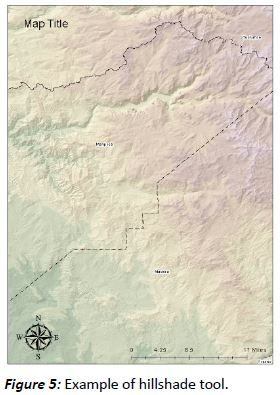

### Part 4. Ethics in Communicating GIS Information

In emergency response fields, such as firefighting, data are shared quickly. In a dynamic situation like a wildfire, the situation changes quickly as well, meaning the minute a map is finalized, the situation on the ground has already changed. As soon as you save/print/email, the data is already old. Map users must understand that even though the maps are made to inform, there is risk in using them. It is your ethical responsibility as a geographer to be transparent in any shortcomings or constraints.  
Write a cover short letter (1/2 to 1/3 page, single spaced) to send with the map information your created for the strike team commander. The cover letter should have a clear disclaimer about the intent of the maps (to provide background/terrain information to support their strategic planning), information about when they were finalized, and how to get in touch with you (i.e. contact info). Include a formal statement modelled off these links, but adapted and streamlined to fit our specific scenario.  
https://gis.stackexchange.com/questions/13514/providing-warnings-and-accuracy-features-on-map-for-legal-reasons  
https://www.aacounty.org/county-maps/data-download/GIS_Disclaimer.pdf  
http://gis.clark.wa.gov/custom52/mapsonline/includes/legal.html  
You’re welcome to search for additional sources for information/inspiration.

## Submission

At the end of this lab, you should have generated the following:  
•(One map: “ned13_slope”)  
•(One map: “ned13_aspect”)  
•(One map: “ned_13_hillshade_rc”)  
•(One map: “ned13_hillshade_1”)  
• One 1/2 to 1/3 page cover letter with ethical disclaimer.

Upload each of these five bullet points into a single PDF with your _accompanying written resopnses as directed in each section to CatCourses.

## References

[1]USGS, The National Map. “Elevation” https://nationalmap.gov/elevation.html  
[2]USGS, The National Map. “3D Elevation Program (3DEP)” https://nationalmap.gov/3DEP/index.html  
[3]USGS ScienceBase-Catalog. “USGS NED n38w119 1/3 arc-second 2013 1 x 1 degree ArcGrid” https://www.sciencebase.gov/catalog/item/581d2249e4b08da350d5478f  
[4]USGS ScienceBase-Catalog. “USGS NED n38w120 1/3 arc-second 2013 1 x 1 degree ArcGrid” https://www.sciencebase.gov/catalog/item/581d2249e4b08da350d54796  
[5] Esri, ArcGIS Pro Documentation. “Slope” https://pro.arcgis.com/en/pro-app/help/data/imagery/slope-function.htm  
[5] Esri, ArcGIS Desktop Documentation. “How Slope works” http://desktop.arcgis.com/en/arcmap/latest/tools/spatial-analyst-toolbox/how-slope-works.htm  
[6] Esri, ArcGIS Desktop Documentation. “How Aspect works” http://desktop.arcgis.com/en/arcmap/latest/tools/spatial-analyst-toolbox/how-aspect-works.htm  
[7] Esri, ArcGIS Blog. “Introducing Esri’s Next Generation Hillshade” https://blogs.esri.com/esri/arcgis/2014/07/14/introducing-esris-next-generation-hillshade/  
[8] Esri, ArcGIS Desktop Documentation. “How Raster Calculator works” http://desktop.arcgis.com/en/arcmap/latest/tools/spatial-analyst-toolbox/how-raster-calculator-works.htm  
[9] Esri, ArcGIS Desktop Documentation. “Overview of the rules for Map Algebra” http://desktop.arcgis.com/en/arcmap/latest/extensions/spatial-analyst/map-algebra/an-overview-of-the-rules-for-map-algebra.htm  
[10] Esri, ArcGIS Desktop Documentation. “What is Map Algebra?” http://desktop.arcgis.com/en/arcmap/latest/extensions/spatial-analyst/map-algebra/what-is-map-algebra.htm  
[11]EDN: ESRI Developer Network. “How Hillshade works” http://edndoc.esri.com/arcobjects/9.2/NET/shared/geoprocessing/spatial_analyst_tools/how_hillshade_works.htm